# Parkinson Meta-Analysis

Sven Kleine Bardenhorst

8 4 2020

# Preparation of data based on same sequence region (V4)

### Load data

```r
# Load ASV data
A_data <- readr::read_delim("Data/A_data.txt",delim="\t")
B_data <- readr::read_delim("Data/B_data.txt",delim="\t")
C_data <- readr::read_delim("Data/C_data.txt",delim="\t")
E_data <- readr::read_delim("Data/E_data.txt",delim="\t")
F_data <- readr::read_delim("Data/F_data.txt",delim="\t")
H_data <- readr::read_delim("Data/H_data.txt",delim="\t")
I_data <- readr::read_delim("Data/I_data.txt",delim="\t")
J_data <- readr::read_delim("Data/J_data.txt",delim="\t")
```

### Transform into tidy format

```r
# transpose into tidy format
A_dat <- tidy_up(A_data,trim=F)
B_dat <- tidy_up(B_data,trim=T)
C_dat <- tidy_up(C_data)
E_dat <- tidy_up(E_data,trim=T)
F_dat <- tidy_up(F_data)
H_dat <- tidy_up(H_data)
I_dat <- tidy_up(I_data)  #%>% mutate(ID = str_replace_all(ID,"-","."))
J_dat <- tidy_up(J_data)
```

### Prepare taxonomy based on V4-region trimmed sequences sequences

```r
studies <- list("A_Dysbiosisofgutmicrobiota",
             "B_Alterationofthefecalmicrobiota_2",
             "C_ColonicbacterialcompositioninParkinson",
             "E_Gutmicrobiotain",
             "F_ThenasalandgutmicrobiomeinParkinsonsdisease",
             "H_EffectofParkinsonsdisease",
             "I_UnravellingGutMicrobiotas")

author.names <- c("Pietrucci et al., 2019",
           "Qian et al., 2018",
           "Keshavarzian et al., 2015",
           "Aho et al., 2019",
           "Heintz-Buschart et al., 2018",
           "Weis et al., 2019",
           "Barichella et al., 2019")

#project_path <- c("G:\\Projects\\ParkinsonMicrobiome\\")
project_path <- c("C:\\Users\\kleinebardenhorst\\Documents\\Projects\\ParkinsonMicrobiome\\ParkinsonMicrobiome\\")



path <- paste0(project_path,"Data\\")
seq_same <- paste("Sequences_sameregion\\")
tax_same <- paste("Classified_sameregion\\Classified_Unaligned_Sliced_F_Sequences_")

taxa <- lapply(studies,function(x) read_tsv(paste0(path,tax_same,x,"_noC.txt.align.fasta"),quote="",col_names = F))
seq <- lapply(studies, function(x) ((seqinr::read.fasta(paste0(path,seq_same,"Unaligned_Sliced_F_Sequences_",x,"_noC.txt.align.fasta"),as.string = T,set.attributes = F))))

seq <- foreach(i=seq_along(seq)) %do% data.frame("ID"=paste0("ASV",names(unlist(seq[[i]]))),"Sequence"=unlist(seq[[i]]))


taxon <- lapply(taxa,prepare_taxonomy_sameregion)

A_tax <- taxon[[1]] %>% left_join(seq[[1]]) %>% apply(2,function(x) gsub('\"', "", x, fixed = TRUE)) %>% as_tibble()
B_tax <- taxon[[2]] %>% left_join(seq[[2]])  %>% apply(2,function(x) gsub('\"', "", x, fixed = TRUE)) %>% as_tibble()
C_tax <- taxon[[3]] %>% left_join(seq[[3]]) %>% apply(2,function(x) gsub('\"', "", x, fixed = TRUE)) %>% as_tibble()
E_tax <- taxon[[4]] %>% left_join(seq[[4]]) %>% apply(2,function(x) gsub('\"', "", x, fixed = TRUE)) %>% as_tibble()
F_tax <- taxon[[5]] %>% left_join(seq[[5]]) %>% apply(2,function(x) gsub('\"', "", x, fixed = TRUE)) %>% as_tibble()
H_tax <- taxon[[6]] %>% left_join(seq[[6]]) %>% apply(2,function(x) gsub('\"', "", x, fixed = TRUE)) %>% as_tibble()
I_tax <- taxon[[7]] %>% left_join(seq[[7]]) %>% apply(2,function(x) gsub('\"', "", x, fixed = TRUE)) %>% as_tibble()
```

### Quality filtering

```r
A_clean <- clean(A_dat,A_tax,filter="rel")
```

```
## Total number of ASVs: 8480
##  20 ASVs filtered due to wrong Kingdom
##  19 ASVs of Class Chloroplast filtered
##  7021 ASVs filtered due to low abundance (< 0.005% )
##  0 ASVs filtered due to low sequence length < 150
##  Number of filtered ASVs: 7060
##  New number of ASVs: 1420
```

```r
B_clean <- clean(B_dat,B_tax,filter="rel")
```

```
## Total number of ASVs: 2674
##  1 ASVs filtered due to wrong Kingdom
##  10 ASVs of Class Chloroplast filtered
##  1708 ASVs filtered due to low abundance (< 0.005% )
##  0 ASVs filtered due to low sequence length < 150
##  Number of filtered ASVs: 1719
##  New number of ASVs: 955
```

```r
C_clean <- clean(C_dat,C_tax,filter="rel")
```

```
## Total number of ASVs: 4770
##  16 ASVs filtered due to wrong Kingdom
##  8 ASVs of Class Chloroplast filtered
##  3711 ASVs filtered due to low abundance (< 0.005% )
##  0 ASVs filtered due to low sequence length < 150
##  Number of filtered ASVs: 3735
##  New number of ASVs: 1035
```

```r
E_clean <- clean(E_dat,E_tax,filter="rel")
```

```
## Total number of ASVs: 9385
##  13 ASVs filtered due to wrong Kingdom
##  13 ASVs of Class Chloroplast filtered
##  8007 ASVs filtered due to low abundance (< 0.005% )
##  0 ASVs filtered due to low sequence length < 150
##  Number of filtered ASVs: 8033
##  New number of ASVs: 1352
```

```r
F_clean <- clean(F_dat,F_tax,filter="rel")
```

```
## Total number of ASVs: 8664
##  37 ASVs filtered due to wrong Kingdom
##  53 ASVs of Class Chloroplast filtered
##  7519 ASVs filtered due to low abundance (< 0.005% )
##  2 ASVs filtered due to low sequence length < 150
##  Number of filtered ASVs: 7611
##  New number of ASVs: 1053
```

```r
H_clean <- clean(H_dat,H_tax,filter="rel")
```

```
## Total number of ASVs: 2757
##  5 ASVs filtered due to wrong Kingdom
##  6 ASVs of Class Chloroplast filtered
##  2025 ASVs filtered due to low abundance (< 0.005% )
##  0 ASVs filtered due to low sequence length < 150
##  Number of filtered ASVs: 2036
##  New number of ASVs: 721
```

```r
I_clean <- clean(I_dat,I_tax,filter="rel")
```

```
## Total number of ASVs: 11253
##  19 ASVs filtered due to wrong Kingdom
##  19 ASVs of Class Chloroplast filtered
##  10255 ASVs filtered due to low abundance (< 0.005% )
##  0 ASVs filtered due to low sequence length < 150
##  Number of filtered ASVs: 10293
##  New number of ASVs: 960
```

```r
#ind <- I_tax[I_tax$Phylum=="Bacteroidetes","ID"] %>% pull

#apply(I_dat[,ind],1,sum)

#I_clean[,names(I_clean) %in% ind]
```

### Prepare metadata

```r
# Load ENA metadata
A_Meta_ENA <- loadENAMeta(path="Data/A_meta_ENA.txt") %>% dplyr::select(run_accession,library_name)
B_Meta_ENA <- loadENAMeta(path="Data/B_meta_ENA.txt")
#C_Meta <- loadENAMeta(path="Data/C_meta.txt")
#D_Meta <- loadENAMeta(path="Data/D_meta.txt")
E_Meta_ENA <- loadENAMeta(path="Data/E_meta_ENA.txt") %>%
  dplyr::select(run_accession,sample_title) %>%
  slice(1:266) %>% # Slice blank controls
  mutate(Timepoint = str_split(.$sample_title," ",simplify = TRUE)[,2],
         Subject = str_split(.$sample_title," ",simplify = TRUE)[,1]) %>%
  dplyr::select(-sample_title)

F_Meta_ENA <- loadENAMeta(path="Data/F_meta_ENA.txt") %>% dplyr::select(run_accession, library_name,experiment_alias)
G_Meta_ENA <- loadENAMeta(path="Data/G_meta_ENA.txt")
H_Meta_ENA <- loadENAMeta(path="Data/H_meta_ENA.txt") %>%
  dplyr::select(run_accession,sample_alias) %>%
  slice(1:256) %>% # Slice ion torrent
  mutate(ID = run_accession,
    Sample = str_split(.$sample_alias,"_",simplify = T)[,1]) %>%
  dplyr::select(ID,Sample)


#I_Meta <- loadENAMeta(path="Data/I_meta.txt")
J_Meta_ENA <- loadENAMeta(path="Data/J_meta_ENA.txt")

# Load detailed metadata
project_path
```

```
## [1] "C:\\Users\\kleinebardenhorst\\Documents\\Projects\\ParkinsonMicrobiome\\ParkinsonMicrobiome\\"
```

```r
C_meta1 <- xlsx::read.xlsx(paste0(project_path,"Data/Meta/C_meta.xlsx"),sheetIndex = 1, header = T,startRow =2)
names <- str_remove(colnames(C_meta1),"PD.")
colnames(C_meta1) <- names

C_meta2 <- xlsx::read.xlsx(paste0(project_path,"Data/Meta/C_meta.xlsx"),sheetIndex = 2, header = T,startRow =2)
names <- str_remove(colnames(C_meta2),"HC.")
colnames(C_meta2) <- names

C_Meta <- C_meta1 %>% full_join(C_meta2) %>% filter(Feces %in% toupper(C_dat$ID) | Tissue %in% toupper(C_dat$ID))

E_meta <- readr::read_csv(paste0(project_path,"Data/Meta/E_meta.csv")) %>%
  left_join(E_Meta_ENA) %>% dplyr::select(run_accession,everything())

H_meta <- xlsx::read.xlsx(paste0(project_path,"Data/Meta/H_meta.xlsx"),
                          sheetIndex = 1, header = T,startRow =1) # Other drugs variable not used and deleted for easier import


I_meta <- xlsx::read.xlsx(paste0(project_path,"Data/Meta/I_meta.xls"), sheetIndex = 1,header=T,startRow = 2) %>% slice(1:306)

J_meta <- readr::read_csv(paste0(project_path,"Data/Meta/J_meta.csv")) %>%
  dplyr::select(cc,ID,Age,Sex,Batch,CC,Onset,'UPDRS-I','UPDRS-III',Stool_freq,Constipation,Vegetarian,Nicotine,Alcohol,Caffeine,Ferm_Milk,Age_DBS,L_Dopa,Benserazid,Carbidopa,Dopa_Agon,COMT_Inhibitor,MAO_B_Inh,CV_disease)
```

### Prepare phyloseq objects

```
## phyloseq-class experiment-level object
## otu_table()   OTU Table:         [ 1420 taxa and 152 samples ]
## sample_data() Sample Data:       [ 152 samples by 4 sample variables ]
## tax_table()   Taxonomy Table:    [ 1420 taxa by 7 taxonomic ranks ]
```

```
## phyloseq-class experiment-level object
## otu_table()   OTU Table:         [ 955 taxa and 90 samples ]
## sample_data() Sample Data:       [ 90 samples by 3 sample variables ]
## tax_table()   Taxonomy Table:    [ 955 taxa by 7 taxonomic ranks ]
```

```
## phyloseq-class experiment-level object
## otu_table()   OTU Table:         [ 1035 taxa and 65 samples ]
## sample_data() Sample Data:       [ 65 samples by 30 sample variables ]
## tax_table()   Taxonomy Table:    [ 1035 taxa by 7 taxonomic ranks ]
```

```
## phyloseq-class experiment-level object
## otu_table()   OTU Table:         [ 1352 taxa and 128 samples ]
## sample_data() Sample Data:       [ 128 samples by 111 sample variables ]
## tax_table()   Taxonomy Table:    [ 1352 taxa by 7 taxonomic ranks ]
```

```
## phyloseq-class experiment-level object
## otu_table()   OTU Table:         [ 1053 taxa and 64 samples ]
## sample_data() Sample Data:       [ 64 samples by 4 sample variables ]
## tax_table()   Taxonomy Table:    [ 1053 taxa by 7 taxonomic ranks ]
```

```
## phyloseq-class experiment-level object
## otu_table()   OTU Table:         [ 721 taxa and 59 samples ]
## sample_data() Sample Data:       [ 59 samples by 17 sample variables ]
## tax_table()   Taxonomy Table:    [ 721 taxa by 7 taxonomic ranks ]
```

```
## phyloseq-class experiment-level object
## otu_table()   OTU Table:         [ 960 taxa and 305 samples ]
## sample_data() Sample Data:       [ 305 samples by 43 sample variables ]
## tax_table()   Taxonomy Table:    [ 960 taxa by 7 taxonomic ranks ]
```

## Filter samples with library size below 10000 reads

```r
A_phyl <- prune_samples(sample_sums(A_phyl)>=10000, A_phyl)
B_phyl <- prune_samples(sample_sums(B_phyl)>=10000, B_phyl) ## 19 Samples filtered
C_phyl <- prune_samples(sample_sums(C_phyl)>=10000, C_phyl) ## 2 samples filtered
E_phyl <- prune_samples(sample_sums(E_phyl)>=10000, E_phyl) ## 2 Samples filtered
F_phyl <- prune_samples(sample_sums(F_phyl)>=10000, F_phyl) ## 1 sample filtered
H_phyl <- prune_samples(sample_sums(H_phyl)>=10000, H_phyl)
I_phyl <- prune_samples(sample_sums(I_phyl)>=10000, I_phyl) ## 47 samples filtered
```

# Data inspection

## Number of taxa per phylum

```r
dat <- list(A_phyl,
            B_phyl,
            C_phyl,
            E_phyl,
            F_phyl,
            H_phyl,
            I_phyl)


fpp <- plyr::ldply(sapply(dat,features_per_phylum),rbind)
rownames(fpp) <- author.names
fpp
```

|  | Acidobacteria | Actinobacteria | Bacteroidetes | Candidatus Saccharibacteria | Elusimicrobia | Firmicutes | Fusobacteria | Lentisphaerae | Proteobacteria | Synergistetes | Tenericutes | Verrucomicrobia | Chloroflexi | Deinococcus-Thermus | Spirochaetes | Hydrogenedentes |
| --- | --- | --- | --- | --- | --- | --- | --- | --- | --- | --- | --- | --- | --- | --- | --- | --- |
| Pietrucci et al., 2019 | 1 | 25 | 483 | 1 | 1 | 779 | 1 | 8 | 103 | 4 | 3 | 11 | NA | NA | NA | NA |
| Qian et al., 2018 | 1 | 36 | 334 | NA | NA | 472 | 10 | NA | 91 | 2 | 1 | 2 | 5 | 1 | NA | NA |
| Keshavarzian et al., 2015 | 3 | 46 | 209 | NA | NA | 683 | 6 | NA | 77 | 2 | 1 | 7 | NA | NA | 1 | NA |
| Aho et al., 2019 | 3 | 18 | 276 | NA | NA | 969 | 3 | 8 | 56 | 5 | 6 | 8 | NA | NA | NA | NA |
| Heintz-Buschart et al., 2018 | 2 | 113 | 202 | 2 | 1 | 478 | 9 | 3 | 234 | 1 | 1 | 4 | NA | 2 | NA | 1 |
| Weis et al., 2019 | NA | 43 | 39 | NA | NA | 611 | NA | 1 | 23 | 1 | NA | 3 | NA | NA | NA | NA |
| Barichella et al., 2019 | 1 | 46 | NA | 1 | 1 | 871 | 3 | 1 | 17 | 9 | 1 | 9 | NA | NA | NA | NA |

## Prevelance and abundance of taxa per phylum

### Pietrucci et al., 2019

```r
prevalence_per_phylum(A_phyl) %>% kable(caption=paste0(author.names[[1]])) %>% kable_styling()
```

Pietrucci et al., 2019

| Phylum | Avg. Prevalence | Total Prevalence |
| --- | --- | --- |
| Acidobacteria | 33.00000 | 33 |
| Actinobacteria | 39.20000 | 980 |
| Bacteroidetes | 14.12008 | 6820 |
| Candidatus Saccharibacteria | 63.00000 | 63 |
| Elusimicrobia | 3.00000 | 3 |
| Firmicutes | 28.09114 | 21883 |
| Fusobacteria | 1.00000 | 1 |
| Lentisphaerae | 25.50000 | 204 |
| Proteobacteria | 15.45631 | 1592 |
| Synergistetes | 12.25000 | 49 |
| Tenericutes | 6.00000 | 18 |
| Verrucomicrobia | 24.36364 | 268 |

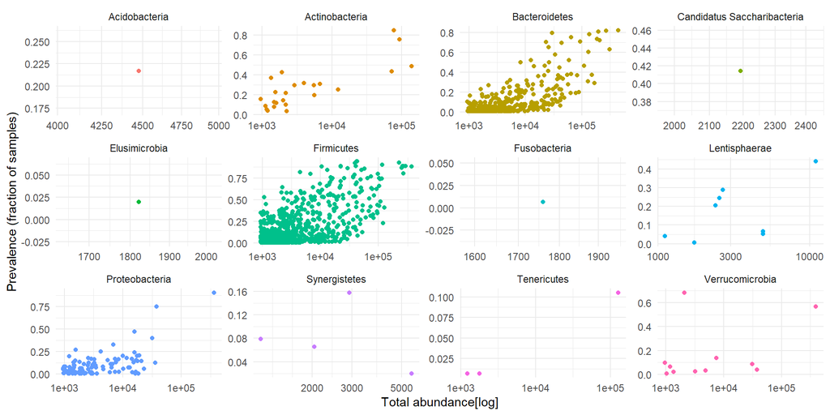

Pietrucci et al., 2019

```r
prevalence_by_abundance(A_phyl,thrs = 0)
```

### Qian et al., 2018

```r
prevalence_per_phylum(B_phyl) %>% kable(caption=paste0(author.names[[2]])) %>% kable_styling()
```

Qian et al., 2018

| Phylum | Avg. Prevalence | Total Prevalence |
| --- | --- | --- |
| Acidobacteria | 3.000000 | 3 |
| Actinobacteria | 3.638889 | 131 |
| Bacteroidetes | 5.898204 | 1970 |
| Chloroflexi | 1.400000 | 7 |
| Deinococcus-Thermus | 1.000000 | 1 |
| Firmicutes | 8.847458 | 4176 |
| Fusobacteria | 2.000000 | 20 |
| Proteobacteria | 6.043956 | 550 |
| Synergistetes | 8.500000 | 17 |
| Tenericutes | 1.000000 | 1 |
| Verrucomicrobia | 1.500000 | 3 |

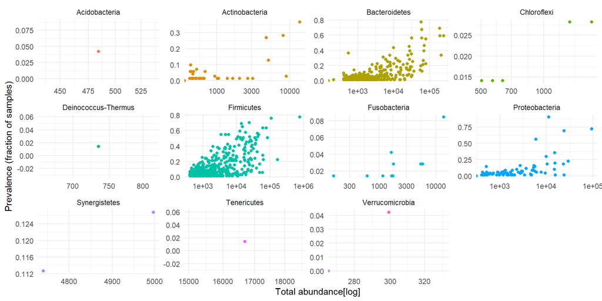

Qian et al., 2018

```r
prevalence_by_abundance(B_phyl,thrs = 0)
```

### Keshavarzian et al., 2015

```r
prevalence_per_phylum(C_phyl) %>% kable(caption=paste0(author.names[[3]])) %>% kable_styling()
```

Keshavarzian et al., 2015

| Phylum | Avg. Prevalence | Total Prevalence |
| --- | --- | --- |
| Acidobacteria | 3.000000 | 9 |
| Actinobacteria | 10.804348 | 497 |
| Bacteroidetes | 6.846890 | 1431 |
| Firmicutes | 10.727672 | 7327 |
| Fusobacteria | 0.500000 | 3 |
| Proteobacteria | 4.519481 | 348 |
| Spirochaetes | 0.000000 | 0 |
| Synergistetes | 10.500000 | 21 |
| Tenericutes | 1.000000 | 1 |
| Verrucomicrobia | 13.857143 | 97 |

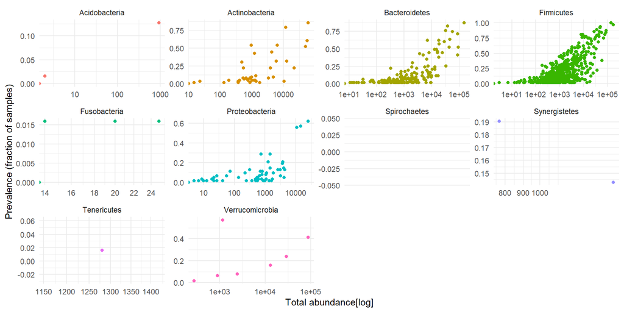

Keshavarzian et al., 2015

```r
prevalence_by_abundance(C_phyl,thrs = 0)
```

- Planctomycetes
- Spirochaetes
- Tenericutes
  - low prevalence
  - one subject on average
  - abundance ~ 1300
- Fusobacteria
  - low prevalence
  - one subject on average
  - suber low abundance < 25

### Aho et al., 2019

```r
prevalence_per_phylum(E_phyl) %>% kable(caption=paste0(author.names[[4]])) %>% kable_styling()
```

Aho et al., 2019

| Phylum | Avg. Prevalence | Total Prevalence |
| --- | --- | --- |
| Acidobacteria | 23.3333333 | 70 |
| Actinobacteria | 33.6111111 | 605 |
| Bacteroidetes | 11.3224638 | 3125 |
| Firmicutes | 23.7471620 | 23011 |
| Fusobacteria | 0.6666667 | 2 |
| Lentisphaerae | 16.7500000 | 134 |
| Proteobacteria | 17.1785714 | 962 |
| Synergistetes | 25.4000000 | 127 |
| Tenericutes | 3.5000000 | 21 |
| Verrucomicrobia | 28.2500000 | 226 |

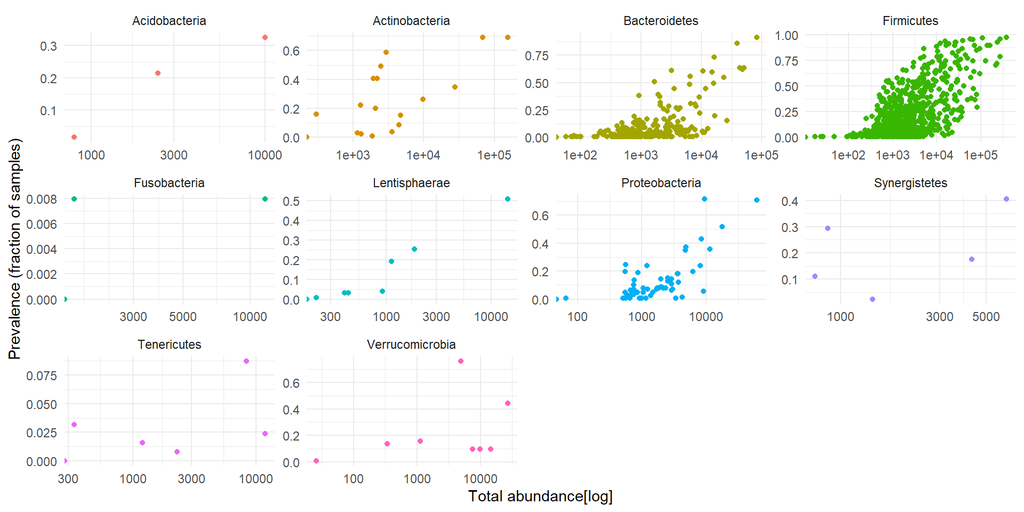

Aho et al., 2019

```r
prevalence_by_abundance(E_phyl,thrs = 0)
```

- Deferribacteres
  - one taxon
  - six subjects
  - low abundance ~ 200
- Elusimicrobia
  - one taxon
  - one subject
  - abundance ~ 500
- Fusobacteria
  - 3 taxa
  - low prevalence < 1
  - extreme range in abundance - 300 < abundance < 10000

### Heintz-Buschart et al., 2018

```r
prevalence_per_phylum(F_phyl) %>% kable(caption=paste0(author.names[[5]])) %>% kable_styling()
```

Heintz-Buschart et al., 2018

| Phylum | Avg. Prevalence | Total Prevalence |
| --- | --- | --- |
| Acidobacteria | 6.500000 | 13 |
| Actinobacteria | 5.150442 | 582 |
| Bacteroidetes | 10.772277 | 2176 |
| Candidatus Saccharibacteria | 0.000000 | 0 |
| Deinococcus-Thermus | 0.000000 | 0 |
| Elusimicrobia | 3.000000 | 3 |
| Firmicutes | 19.633891 | 9385 |
| Fusobacteria | 1.555556 | 14 |
| Hydrogenedentes | 0.000000 | 0 |
| Lentisphaerae | 15.666667 | 47 |
| Proteobacteria | 2.440171 | 571 |
| Synergistetes | 22.000000 | 22 |
| Tenericutes | 0.000000 | 0 |
| Verrucomicrobia | 18.000000 | 72 |

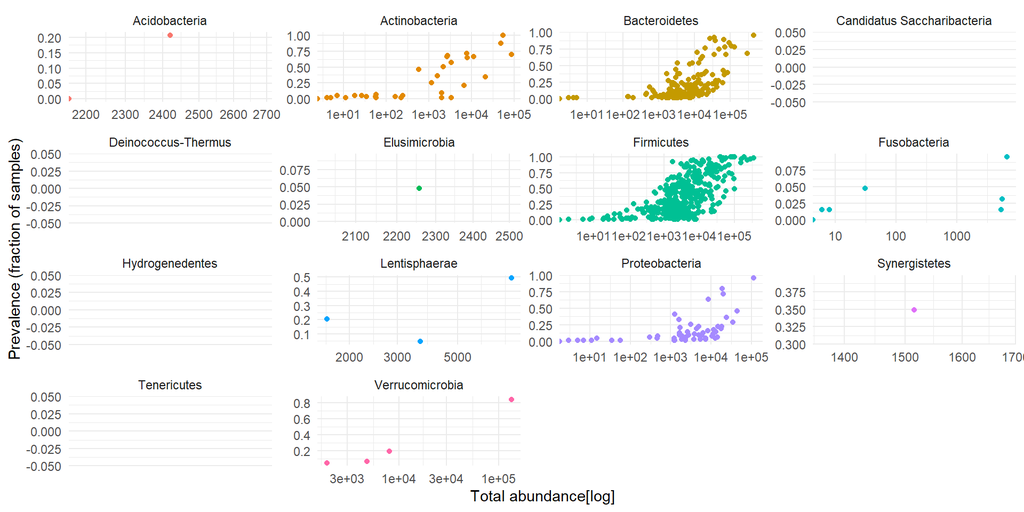

Heintz-Buschart et al., 2018

```r
prevalence_by_abundance(F_phyl,thrs = 0)
```

- Armatimonadetes
- candidate division WPS-1
- candidate division WPS-2
- Chloroflexi
- Chrysiogenetes
- Deferribacteres
- Deinococcus-Thermus
- Gemmatimonadetes
- Hydrogenedentes
- Ignavibacteriae
- Planctomycetes
- Spirochaetes
- Elusimicrobia
  - one taxon
  - three subjects
  - abundance ~ 2000

### Weis et al., 2019

```r
prevalence_per_phylum(H_phyl) %>% kable(caption=paste0(author.names[[6]])) %>% kable_styling()
```

Weis et al., 2019

| Phylum | Avg. Prevalence | Total Prevalence |
| --- | --- | --- |
| Actinobacteria | 11.441861 | 492 |
| Bacteroidetes | 4.435897 | 173 |
| Firmicutes | 8.314239 | 5080 |
| Lentisphaerae | 2.000000 | 2 |
| Proteobacteria | 5.000000 | 115 |
| Synergistetes | 2.000000 | 2 |
| Verrucomicrobia | 10.666667 | 32 |

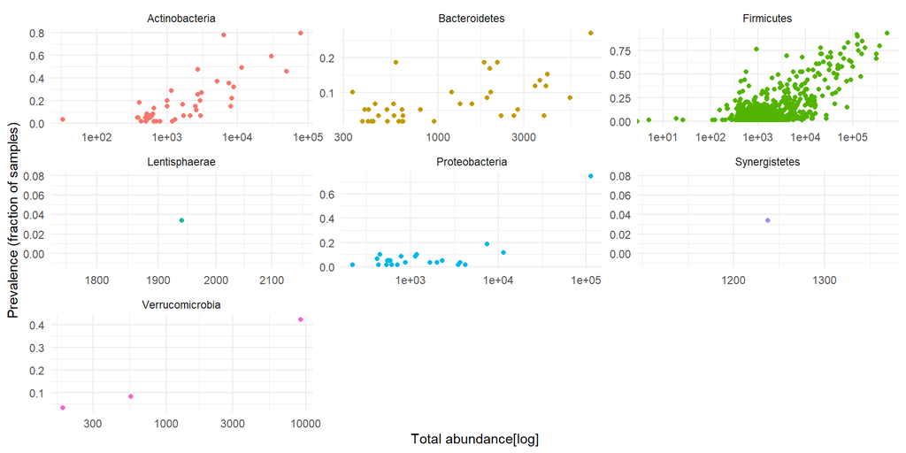

Weis et al., 2019

```r
prevalence_by_abundance(H_phyl,thrs = 0)
```

- Chloroflexi
  - one taxon
  - one subject
  - low abundance < 200
- Tenericutes
  - three taxa
  - two subjects
  - low abundance < 350

### Barichella et al., 2019

```r
prevalence_per_phylum(I_phyl) %>% kable(caption=paste0(author.names[[7]])) %>% kable_styling()
```

Barichella et al., 2019

| Phylum | Avg. Prevalence | Total Prevalence |
| --- | --- | --- |
| Acidobacteria | 53.000000 | 53 |
| Actinobacteria | 38.782609 | 1784 |
| Candidatus Saccharibacteria | 80.000000 | 80 |
| Elusimicrobia | 2.000000 | 2 |
| Firmicutes | 37.772675 | 32900 |
| Fusobacteria | 3.333333 | 10 |
| Lentisphaerae | 8.000000 | 8 |
| Proteobacteria | 19.705882 | 335 |
| Synergistetes | 18.333333 | 165 |
| Tenericutes | 1.000000 | 1 |
| Verrucomicrobia | 38.333333 | 345 |

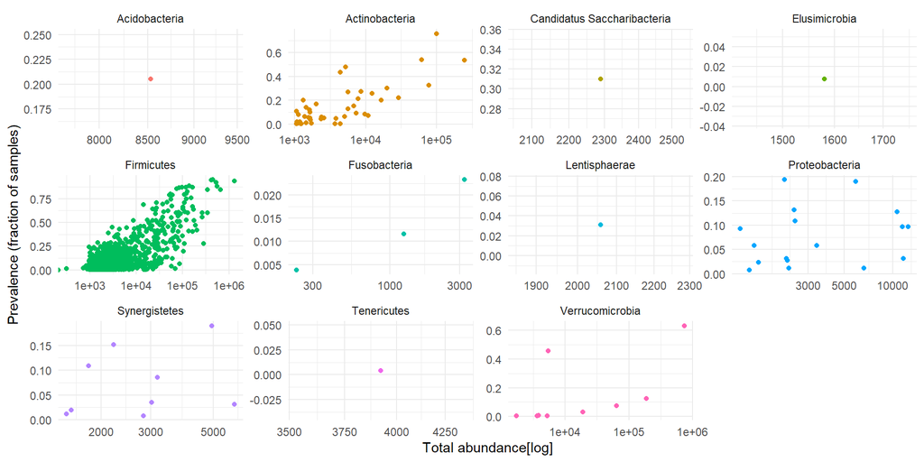

Barichella et al., 2019

```r
prevalence_by_abundance(I_phyl,thrs = 0)
```

- Deferribacteres
  - one taxon
  - three subjects
  - low abundance < 400
- Elusimicrobia
  - one taxon
  - two subjects
  - abundance ~ 1600
- Tenericutes
  - one taxon
  - one subject
  - abundance ~ 4000

# Pooled analysis of alpha diversity

## Prepare alpha diversity measures

```r
dat <- list(A_phyl,
            B_phyl,
            C_phyl,
            E_phyl,
            F_phyl,
            H_phyl,
            I_phyl)

alpha_dat <- estimate_alpha(dat)
```

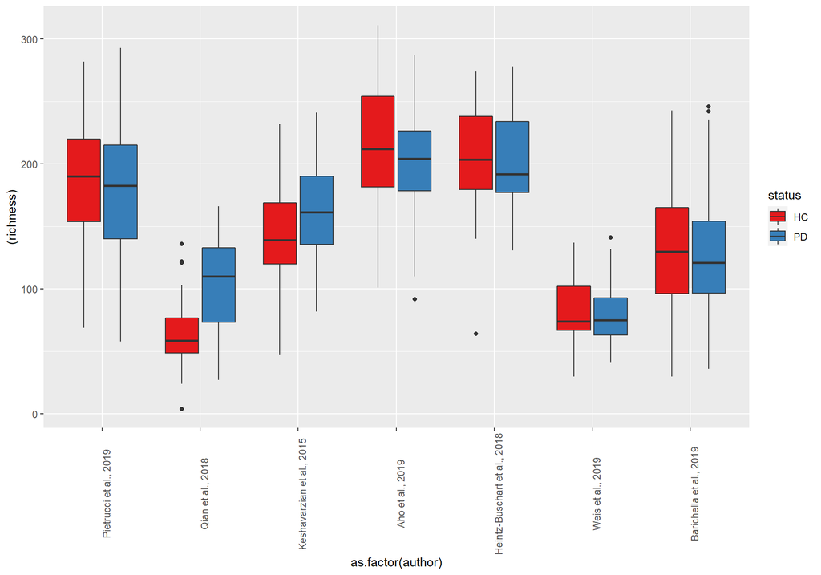

```r
ggplot(aes(x=as.factor(author),y=(richness)),data=alpha_dat) +
  geom_boxplot(aes(fill=status)) +
  scale_fill_brewer(palette = "Set1") +
  theme(axis.text.x = element_text(angle = 90))
```

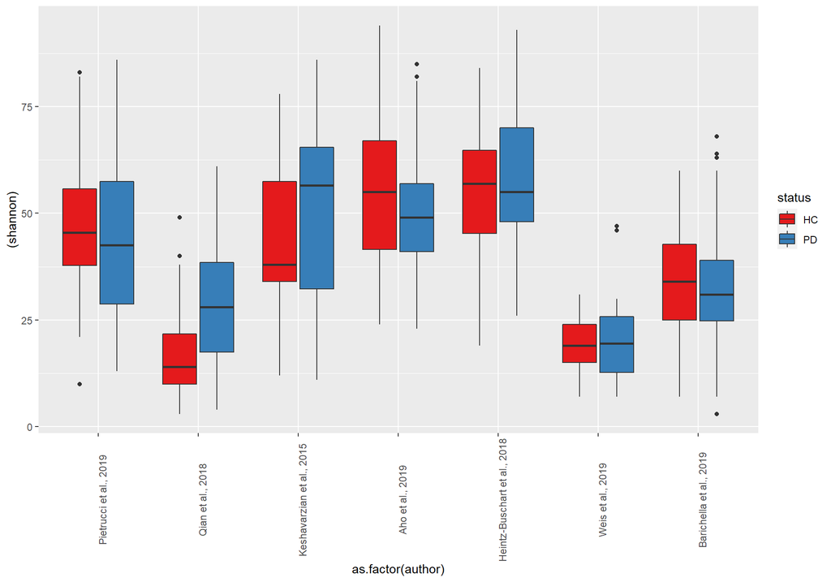

```r
ggplot(aes(x=as.factor(author),y=(shannon)),data=alpha_dat) +
  geom_boxplot(aes(fill=status)) +
  scale_fill_brewer(palette = "Set1") +
  theme(axis.text.x = element_text(angle = 90))
```

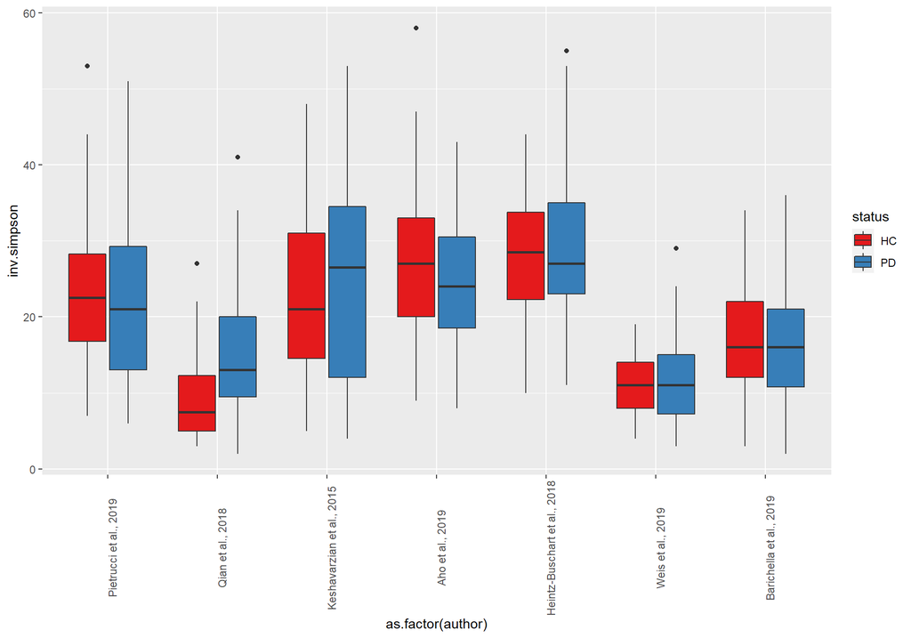

```r
ggplot(aes(x=as.factor(author),y=inv.simpson),data=alpha_dat) +
  geom_boxplot(aes(fill=status)) +
   scale_fill_brewer(palette = "Set1") +
  theme(axis.text.x = element_text(angle = 90))
```

## Estimate alpha diversity by effective number of taxa through hill numbers

The problems with indices like Simpson or Shannon is that they are not diversities by themselves, but only proxies (indices) of the true underlying diversity. However, often every index is treated like a true diversity, which may lead to misleading results for several reasons. At first, indices define diversity in different ways, e.g. some focus solely on the number of present taxa (further referred to as richness), while others incorporate the relative abundance of all present taxa (further referred to as eveness). The combination of speciess richness and eveness into one index makes it hard to interpret. It further leads to the second problem, that some indices do NOT double when the true diversity doubles, hence, they are highly non-linear. As an example, a community with a Shannon-Index ($H'$) of 2 is not twice as diverse as a community with a $H'$ of 1. In addition, on the $H'$-scale, the difference between 1 and 2 is not equal to the difference between 3 and 4. Thus, the location of a mean difference on the $H'$-scale matters. This makes the statisical analysis and interpretation of alpha diversity indices problematic. However, there is a straightforward and intuitive way to define a true diversity in terms of **effective number of species** through hill numbers.

```r
x <- rep(150,50)
shannon <- function(x) {-sum( (x/sum(x)) * log(x/sum(x)) )}
s_x <- shannon(x)
```

Given a specific value of $H'$, we cannot derive the true diversity of the community, as we cannot decompose the value into its richness and eveness parts. However, we still know that two communities with an equal index are always equally diverse.

Suppose we have two communities with 50 equally abundant taxa. We can calculate the Shannon-Index for this community with

$$H' = - \sum_i p_i * ln p_i$$

with $p_i = \frac{n_i}{N}$. For the given example, $H'$ is 3.912023. Now, we know the $H'$ of a community with 50 equally abundant taxa. Therefore, we can conclude that every community with an $H'$ of 3.912023 is always as diverse as a community with 50 equally abundant taxa.

We can make use of this fact, by transforming the $H'$ into the **effective number of species**, which is simply done by exponantation of $H'$.

$$\exp(H') = exp(3.912023) = 50$$
The same logic can be applied to other measures of diversity. In fact, the effective number of species based on the most commonly used diversity indices can be calculated directly by the generalized formula

$$qD = (\sum_{i_=1}^Sp_i^q)^{1/(1-q)},$$
which is the Hill number of order q. The expression if fully dependent on the choice of q, the exponent of taxa abundances, thus, determining the weight that is assigned to the evenness of taxa. The higher the value of q, the higher the influence of eveness on the value of the index.

Different values of q correspond to the most frequently used diversity measures. Here, we will focus on $q=0$ (species richness), $q=1$ (exponential of the Shannon index; note that it is not exactly 1, as the formula is not defined for $q=1$, but its limit when q tends to 1) and $q=2$ (the inverse of Simpson’s concentration index).

### Alpha diveristy analysis through hill numbers

A common problem with all diversity indices is their dependency on the sampling depth (library size). We can inspect this dependency by correlating the value of the hill numbers of different order with the respective library size.

```r
## Asses whether alpha-diversity associated with sequencing depth
alpha_dat %>% group_by(author) %>% summarize(Richness = round(cor(richness,N),2),
                                             Shannon = round(cor(shannon,N),2),
                                             "Inverse simpson" = round(cor(inv.simpson,N),2)) %>% column_to_rownames("author") %>% t %>% kable(caption = "Correlation of alpha diversity indices with library size") %>% kableExtra::kable_styling("striped")
```

Correlation of alpha diversity indices with library size

|  | Pietrucci et al., 2019 | Qian et al., 2018 | Keshavarzian et al., 2015 | Aho et al., 2019 | Heintz-Buschart et al., 2018 | Weis et al., 2019 | Barichella et al., 2019 |
| --- | --- | --- | --- | --- | --- | --- | --- |
| Richness | 0.51 | 0.58 | 0.43 | 0.37 | 0.48 | 0.56 | 0.60 |
| Shannon | 0.28 | 0.34 | 0.15 | -0.08 | 0.31 | 0.02 | 0.15 |
| Inverse simpson | 0.21 | 0.24 | 0.07 | -0.14 | 0.33 | -0.07 | 0.03 |

In our setting, this challenge is even more complex, as the library size is not only different between individuals, but also cluster within studies and sometimes within study groups nested in these studies.

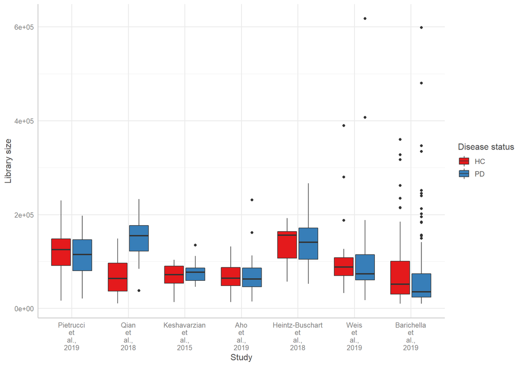

Average library size per study and per study group.

```r
#alpha_dat %>% group_by(author,status) %>% summarize(avg_LS = mean(N)) %>%
#  ggplot(aes(x=author,y=avg_LS,fill=status)) +
#  geom_bar(stat="identity",position = "dodge") +
#   scale_fill_brewer(palette="Set1") +
#  scale_x_discrete(labels=addline_format(unique(alpha_dat$author))) +
#  theme_sjplot()

alpha_dat %>%
  ggplot(aes(x=author,y=N,fill=status)) +
  geom_boxplot() +
   scale_fill_brewer(palette="Set1") +
  scale_x_discrete(labels=addline_format(unique(alpha_dat$author))) +
  theme_sjplot() +
  ylab("Library size") +
  xlab("Study") +
  labs(fill="Disease status")
```

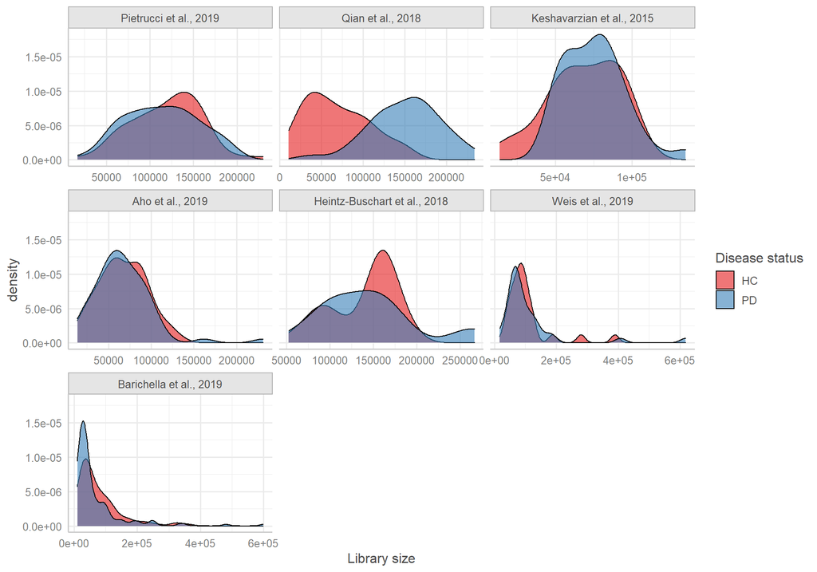

Distribution of library size per study and per study group.

```r
alpha_dat %>% dplyr::select(status,N,study) %>%
  ggplot(aes(x=N,fill=status)) +
  geom_density(alpha=.6) +
  scale_fill_brewer(palette="Set1") +
  facet_wrap(~alpha_dat$author,ncol = 3,scales = "free_x") +
  theme_sjplot() +
  xlab("Library size") +
  labs(fill="Disease status")
```

A common approach to handle unequal library sizes is by rarefaction, thus, sub-sampling from each sample to achieve equal library sizes that allow for fair comparisons However, this approach is highly criticized for several reasons, among which is the discarding of valuable data. Therefore, we will use a poisson model including the library size as an offset, conditioning the estimates on the library size. Using this approach, we will incorporate the uncertainty associated with the library size (cases will be weighted according to their library size), without throwing away any information.

## Random Effects models for alpha diversity

## Two-stage approach

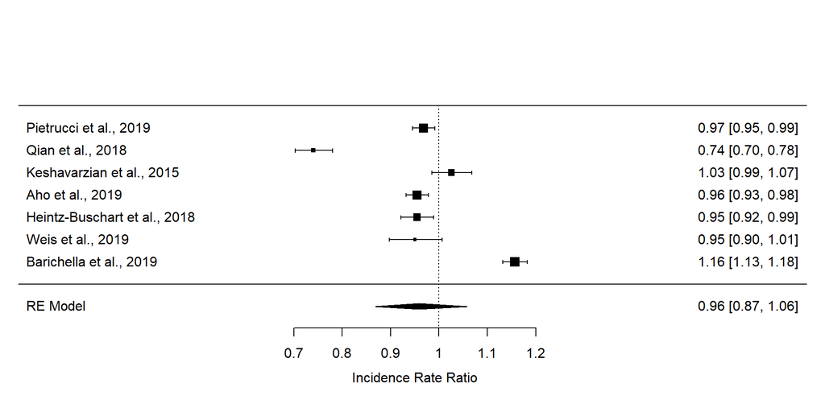

Two stage meta-analysis using poisson regression with library size as offset - richness.

```r
alpha_dat2 <- alpha_dat %>% dplyr::select(ID,status,everything()) %>% filter(N>10)

## metafor two-stage approach
library(metafor)

met_dat <- alpha_dat2 %>%
  dplyr::select(study,status,richness,N,author) %>%
  group_by(study,status) %>%
  summarise(richness = sum(richness),
            N = sum(N),
            author = first(author)) %>%
  pivot_wider(names_from=status,values_from=c(richness,N))

res <- rma(measure = "IRR",x2i=richness_HC,x1i=richness_PD,t2i=N_HC,t1i=N_PD,data=met_dat)

forest(res,transf = exp,refline = 1,slab = unique(alpha_dat2$author))
```

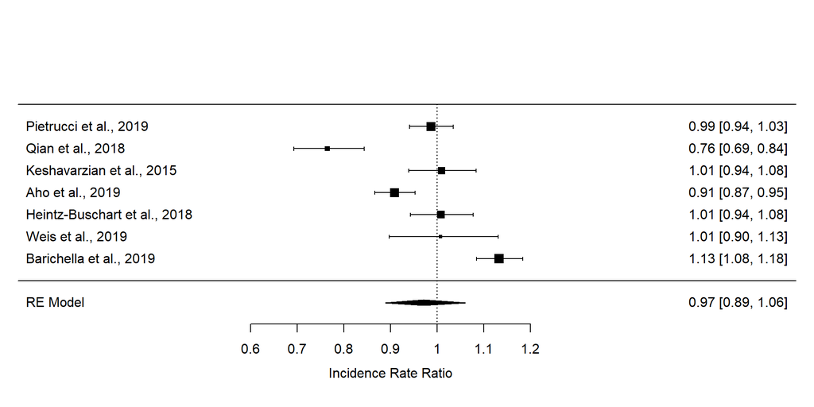

Two stage meta-analysis using poisson regression with library size as offset - shannon.

```r
## metafor two-stage approach

met_dat <- alpha_dat2 %>%
  dplyr::select(study,status,shannon,N,author) %>%
  group_by(study,status) %>%
  summarise(shannon = sum(shannon),
            N = sum(N),
            author = first(author)) %>%
  pivot_wider(names_from=status,values_from=c(shannon,N))

res <- rma(measure = "IRR",x2i=shannon_HC,x1i=shannon_PD,t2i=N_HC,t1i=N_PD,data=met_dat)

forest(res,transf = exp,refline = 1,slab = unique(alpha_dat2$author))
```

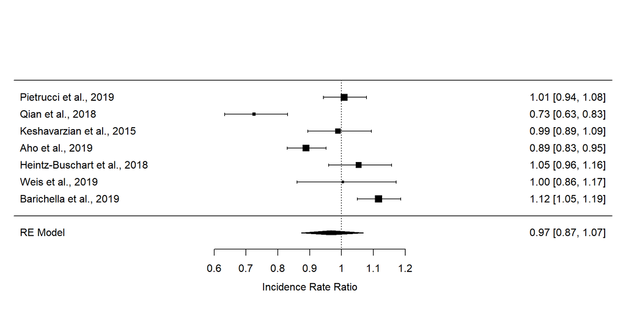

Two stage meta-analysis using poisson regression with library size as offset - inv.simpson

```r
## metafor two-stage approach
met_dat <- alpha_dat2 %>%
  dplyr::select(study,status,inv.simpson,N,author) %>%
  group_by(study,status) %>%
  summarise(inv.simpson = sum(inv.simpson),
            N = sum(N),
            author = first(author)) %>%
  pivot_wider(names_from=status,values_from=c(inv.simpson,N))

res <- rma(measure = "IRR",x2i=inv.simpson_HC,x1i=inv.simpson_PD,t2i=N_HC,t1i=N_PD,data=met_dat)

forest(res,transf = exp,refline = 1,slab = unique(alpha_dat2$author))
```